# **Trent Rivers Final Project**

## **Greetings!**

Youtube demonstration link: https://youtu.be/SiWMSBQ5s2g

Github link: https://github.com/trentbrivers/RLGymnasium/tree/main

To conclude the CSPB 3202 Artificial Intelligence course, this project is meant to put Reinforcement learning into practice. Using the OpenAI/Farama gymnasium library, the goal is to train a computer controlled agent to solve a novel problem within a simulated environment.

In this particular project, I am going to be attempting to solve the Bipedal Walker environment. This environment was selected because I am particularly interested in Machine Learning enabled locomotion. This environment allows me to experiment with that without dealing with the dependencies and installations required for more complex MuJoCo environments provided in Gymnasium. This environment also provides the agent with a greater range of options since we are not using discrete action values. I'm interested to see the results.

```python
#Handling proper libraries.
!pip install gymnasium
!pip install swig
!pip install gymnasium[box2d]
!pip install matplotlib
```

```
  Using cached gymnasium-1.1.1-py3-none-any.whl (965 kB)
  Using cached Farama_Notifications-0.0.4-py3-none-any.whl (2.5 kB)
  Using cached swig-4.3.1-py3-none-manylinux_2_12_x86_64.manylinux2010_x86_64.whl (1.9 MB)
  Using cached pygame-2.6.1-cp310-cp310-manylinux_2_17_x86_64.manylinux2014_x86_64.whl (14.0 MB)
  Using cached box2d_py-2.3.5-cp310-cp310-linux_x86_64.whl
```

```python
import gymnasium as gym
%matplotlib inline
import matplotlib.pyplot as plt
from IPython import display
import numpy as np
from collections import defaultdict
```

```python
#Code taken from the cartpole-updated notebook

def show_state(env, step=0, info=""):
    plt.figure(3)
    plt.clf()
    plt.imshow(env.render())
    plt.title("%s | Step: %d %s" % (env.spec.id,step, info))
    plt.axis('off')

    display.clear_output(wait=True)
    display.display(plt.gcf())

def replay(env, policy):
    #obs = env.reset()
    step = 0
    for a in policy:
        env.step(a)
        show_state(env, step)
        step+=1
```

## **The Environment**

The Bipedal Walker environment uses a 4-jointed walker to traverse a 2D environment - it's like a box with two simple legs. The actions available are motor speed values in the range -1, 1 for each of the 4 joints.

The bipedal walker agent accumulates rewards by moving forward (to the right), up to 300+ at the far end. If it falls, it immediately receives -100 points and the episode is terminated. According to the documentation, this problem is "solved" when the agent can clear 300 points in 1600 time steps on normal mode (slightly bumpy terrain) or 2000 time steps in hardcore mode (with obstacles the agents will need to overcome).

Let's test the performance of a random agent below to establish a baseline.

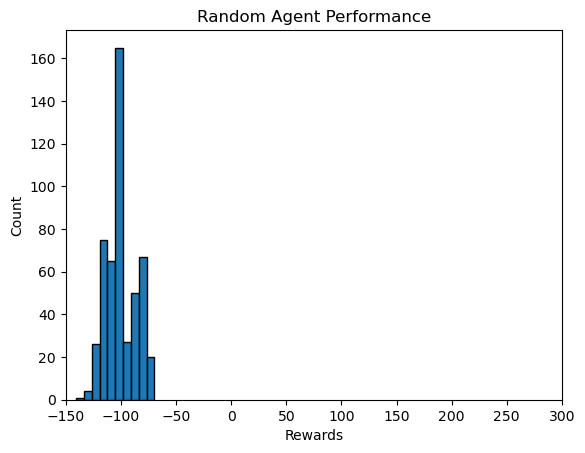

```python
def oneEpisode(env):
    total_reward = 0.0
    total_steps = 0
    obs = env.reset()
    policy = []

    while total_steps < 1600:
        action = env.action_space.sample() #.sample method gives a random action sample
        obs, reward, done, trunc, _ = env.step(action)
        policy.append(action)
        total_reward += reward
        total_steps += 1
        if done or trunc:
            break

    return total_reward, policy

def runMultipleEpisodes(iterations, env):
    best_reward = float('-inf')
    rewards = []
    best_policy = []
    for i in range(iterations):
        r, p = oneEpisode(env)
        rewards.append(r)
        if r > best_reward:
            best_reward = r
            best_policy = p
    return rewards, best_policy

env = gym.make("BipedalWalker-v3", render_mode = "rgb_array")

rewards, best_policy = runMultipleEpisodes(500, env)

plt.hist(rewards, edgecolor='black')
plt.xlim(-150, 300)
plt.xlabel("Rewards")
plt.ylabel("Count")
plt.title("Random Agent Performance")
plt.show()
#now = datetime.datetime.now()
#current_time = now.strftime("%H-%M-%S")
#plt.savefig("figure"+str(current_time) + ".png")
```

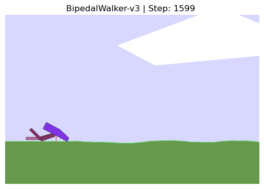

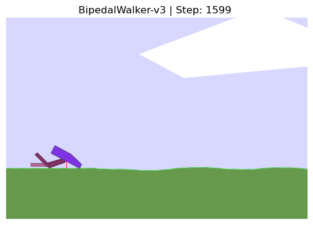

```python
replay(env, best_policy)
```

```python
env.action_space.sample()
```

```
array([ 0.7900793 , -0.04229216, -0.18974346,  0.60722244], dtype=float32)
```

## **I have encountered a problem**

I have a hit a brick wall. Let me explain. This particular problem encodes action as a 4-vector of floating point values in the range -1, 1. Since actions are a vector of floating points and not discrete values, the possible combinations of state-action pairs for something like q-learning are almost innumerable. This makes Q-learning unfeasible because we can not tabulate all of the possible Q-values.

The second is that, given the structure of Gymnasium and the Env class, the information we have access to about the environment is extremely limited. Since information is so limited, it is not possible, at least in my present view, to implement approximate Q-Learning with a feature based representation because there is no way to define the necessary features.

Another bottleneck is that Bipedal Walker takes noticably longer to run each episode than other environments. If you are going through this notebook, it will probably take around 2 minutes to just run 500 episodes. To perform the learning necessary, with tens of thousands of episodes, I deem this too slow for the moment.

I had initially thought this was an interesting environment because of the range of action values possible. However, in light of these challenges, which I'm currently unable to resolve, I will be changing course to focus on a different Gymnasium environment: Taxi.

## **Environment 2: Taxi**

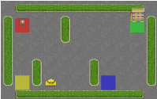

The Taxi environment is simple: there are four-color coded pick-up and drop-off locations - Red, Green, Yellow, and Blue - among a 5x5 grid world. The agent's goal is to traverse the grid world to a "passenger" at one of these four colored spaces, "pick them up" (use the "Pickup Passenger" action), move to the desired dropoff colored spot, and use the "Drop off Passenger" action to complete the journey.

The observation space consists of 500 discrete states: 25 taxi positions in the grid world, 5 possible locations of the passenger (including inside the taxi), and 4 destination locations. The environment is initialized to one of 300 possible starting states, where the taxi is placed in one of the 25 possible grid world locations, the passenger is on one of the 4 colored pick-up/drop-off points, and 3 possible destinations (the other colored spaces not occupied by the passenger). The taxi agent may use 6 different actions at any point: move south, move north, move east, move west, pickup passenger, and drop off passenger.

Rewards are accrued in one of three ways: +20 for delivering the passenger, -10 for illegally executing a pickup or dropoff action, and -1 per time step when no other reward is triggered.

The episode ends when the taxi drops off the passenger. If the time_limit wrapper is being used, then the episode can end when the episode length is 200.

### **Random Agent Test**

Once again, let's start with a random agent to test performance within this environment.

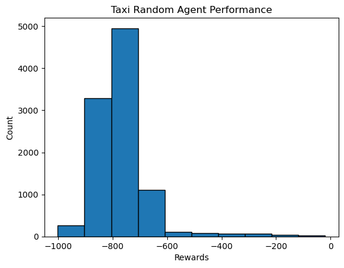

```python
from gymnasium.wrappers import TimeLimit
env = gym.make("Taxi-v3", render_mode = "rgb_array")
env = TimeLimit(env, 1500)

random_rewards, best_policy = runMultipleEpisodes(10000, env)

plt.hist(random_rewards, edgecolor='black')
plt.xlabel("Rewards")
plt.ylabel("Count")
plt.title("Taxi Random Agent Performance")
plt.show()
```

[figure not shown]

[figure not shown]

```python
replay(env, best_policy)
```

Like the bipedal walker, what you should see above is that though the current best policy from a random agent may terminate fairly quickly, it does not work in most circumstances due to the different possible starting locations. This is obviously not optimal, and it does not solve the problem. There is work that need to be done in order to fix that.

### **Test 1: SARSA/Epsilon Greedy Agent**

The documentation for Gymnasium includes code for an agent that solves Blackjack. That code has been modified here to act as an epsilon greedy/Sarsa agent in the Taxi environment. A Sarsa agent is a reinforcement learning agent that works on-policy. That has consequences for the results we are likely to observe because the policy being operated under is the policy being modified.

The formula for SARSA updates is: $$Q(s_t,a_t)\leftarrow + \alpha(r_{t+1}+\gamma Q(s_{t+1},a_{t+1})-Q(s_t,a_t))$$

```python
from collections import defaultdict

class TaxiAgent:
    def __init__(
        self,
        env: gym.Env,
        learning_rate: float,
        initial_epsilon: float,
        epsilon_decay: float,
        final_epsilon: float,
        discount_factor: float = 0.95,
    ):
        """Initialize a Reinforcement Learning agent with an empty dictionary
        of state-action values (q_values), a learning rate and an epsilon.

        Args:
            env: The training environment
            learning_rate: The learning rate
            initial_epsilon: The initial epsilon value
            epsilon_decay: The decay for epsilon
            final_epsilon: The final epsilon value
            discount_factor: The discount factor for computing the Q-value
        """
        self.env = env
        self.q_values = defaultdict(lambda: np.zeros(env.action_space.n))

        self.lr = learning_rate
        self.discount_factor = discount_factor

        self.epsilon = initial_epsilon
        self.epsilon_decay = epsilon_decay
        self.final_epsilon = final_epsilon

        self.training_error = []

    def get_action(self, obs: int) -> int:
        """
        Returns the best action with probability (1 - epsilon)
        otherwise a random action with probability epsilon to ensure exploration.
        """
        # with probability epsilon return a random action to explore the environment
        if np.random.random() < self.epsilon:
            return self.env.action_space.sample()
        # with probability (1 - epsilon) act greedily (exploit)
        else:
            return int(np.argmax(self.q_values[obs]))

    def update(
        self,
        obs: int,
        action: int,
        reward: float,
        terminated: bool,
        next_obs: int,
        future_action: int,
    ):
        """Updates the Q-value of an action."""
        future_q_value = self.q_values[next_obs][future_action]
        temporal_difference = (reward + self.discount_factor * future_q_value - self.q_values[obs][action]) # R + dis*max(Q(s',a') - Q(s,a)

        self.q_values[obs][action] = (
            self.q_values[obs][action] + self.lr * temporal_difference
        )
        self.training_error.append(temporal_difference)

    def decay_epsilon(self):
        self.epsilon = max(self.final_epsilon, self.epsilon - self.epsilon_decay)
```

```python
# hyperparameters
learning_rate = 0.01
n_episodes = 50_000
start_epsilon = 1.0
epsilon_decay = start_epsilon / (n_episodes / 2)  # reduce the exploration over time
final_epsilon = 0.1

env = gym.make("Taxi-v3", render_mode = "rgb_array")
env = TimeLimit(env, 1500)
env = gym.wrappers.RecordEpisodeStatistics(env, buffer_length=n_episodes)

agent = TaxiAgent(
    env=env,
    learning_rate=learning_rate,
    initial_epsilon=start_epsilon,
    epsilon_decay=epsilon_decay,
    final_epsilon=final_epsilon,
)
```

```python
from tqdm import tqdm

for episode in tqdm(range(n_episodes)):
    obs, info = env.reset()
    done = False
    action = agent.get_action(obs)

    # play one episode
    while not done:
        next_obs, reward, terminated, truncated, info = env.step(action)
        next_action = agent.get_action(next_obs)

        # update the agent
        agent.update(obs, action, reward, terminated, next_obs, next_action)
        action = next_action

        # update if the environment is done and the current obs
        done = terminated or truncated
        obs = next_obs

    agent.decay_epsilon()
```

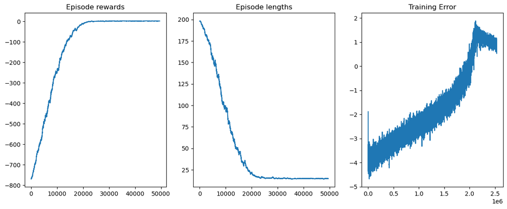

```python
from matplotlib import pyplot as plt

def get_moving_avgs(arr, window, convolution_mode):
    return np.convolve(
        np.array(arr).flatten(),
        np.ones(window),
        mode=convolution_mode
    ) / window

# Smooth over a 500 episode window
rolling_length = 500
fig, axs = plt.subplots(ncols=3, figsize=(12, 5))

axs[0].set_title("Episode rewards")
reward_moving_average = get_moving_avgs(
    env.return_queue,
    rolling_length,
    "valid"
)
axs[0].plot(range(len(reward_moving_average)), reward_moving_average)

axs[1].set_title("Episode lengths")
length_moving_average = get_moving_avgs(
    env.length_queue,
    rolling_length,
    "valid"
)
axs[1].plot(range(len(length_moving_average)), length_moving_average)

axs[2].set_title("Training Error")
training_error_moving_average = get_moving_avgs(
    agent.training_error,
    rolling_length,
    "same"
)
axs[2].plot(range(len(training_error_moving_average)), training_error_moving_average)
plt.tight_layout()
plt.show()
```

```python
def runEpisodeQAgent(agent):
    total_rewards = 0
    obs, info = env.reset()
    done = False
    #step = 0

    # play one episode
    while not done:
        #show_state(env, step)
        #step += 1
        action = agent.get_action(obs)
        next_obs, reward, terminated, truncated, info = env.step(action)
        total_rewards += reward

        # update if the environment is done and the current obs
        done = terminated or truncated
        obs = next_obs
    return total_rewards

def visualizeAgentEpisode(agent, env):
    total_rewards = 0
    obs, info = env.reset()
    done = False
    step = 0

    # play one episode
    while not done:
        show_state(env, step)
        step += 1
        action = agent.get_action(obs)
        next_obs, reward, terminated, truncated, info = env.step(action)
        total_rewards += reward

        # update if the environment is done and the current obs
        done = terminated or truncated
        obs = next_obs
```

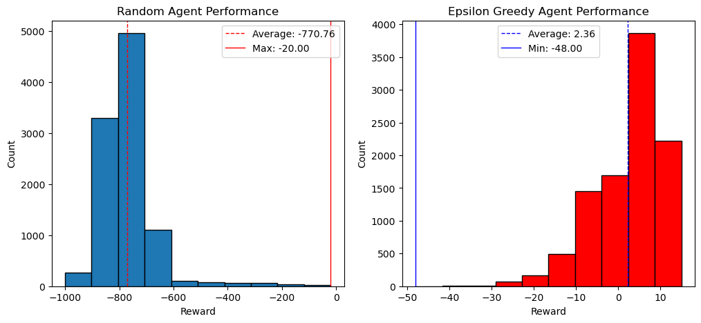

```python
e_greedy_agent_rewards = [runEpisodeQAgent(agent) for i in range(10000)]

random_average = np.mean(random_rewards)
random_max = np.max(random_rewards)
e_greedy_average = np.mean(e_greedy_agent_rewards)
e_greedy_min = np.min(e_greedy_agent_rewards)

fig, axs = plt.subplots(ncols=2, figsize=(12, 5))

axs[0].hist(random_rewards, edgecolor='black')
axs[0].set_title("Random Agent Performance")
axs[0].set_xlabel("Reward")
axs[0].set_ylabel("Count")
axs[0].axvline(random_average, color='red', linestyle='dashed', linewidth=1, label=f'Average: {random_average:.2f}')
axs[0].axvline(random_max, color='red', linewidth=1, label=f'Max: {random_max:.2f}')
axs[0].legend()

axs[1].hist(e_greedy_agent_rewards, edgecolor='black', color= 'red')
axs[1].set_title("Epsilon Greedy Agent Performance")
axs[1].set_xlabel("Reward")
axs[1].set_ylabel("Count")
axs[1].axvline(e_greedy_average, color='blue', linestyle='dashed', linewidth=1, label=f'Average: {e_greedy_average:.2f}')
axs[1].axvline(e_greedy_min, color='blue', linewidth=1, label=f'Min: {e_greedy_min:.2f}')
axs[1].legend()

plt.show()
```

## **Performance Compared**

In comparing the above plots, it's obvious that the Epsilon Greedy agent is orders of magnitude better than the random agent. The absolute worst performance seen by the Epsilon Greedy agent is not far off from the maximum performance produced by the random agent. The difference in their average performance is also a clear indication of how much better the trained Epsilon Greedy agent is: where the random agent's average performance is around -770, the Epsilon Greedy agent's performance is positive. You can view a random episode below to see that the trained agent will complete the task.

[figure not shown]

[figure not shown]

```python
visualizeAgentEpisode(agent, env)
```

## **Epsilon Greedy is Not Optimal**

From our time in this course, we know that on-policy RL models, like epsilon greedy, are suboptimal. You may even see this in the above visualization - the agent may lose its course momentarily before finding its way again in some trials. Though the problem has been solved, the solution is not optimal. Is it possible to push performance further and come up with an optimal policy for this environment?

## **Test 2: Towards an Optimal Policy**

Epsilon Greedy is suboptimal because, as an on-policy strategy, it modifies the policy it is currently operating under. All efforts to explore new policy options undermine the established policy to eploit. There is another option which may be suitable to this scenario: Q-learning. Since Q-learning can occur off-policy using a target policy to optimize and a behavior policy to explore, it can converge to an optimal policy while still exploring the environment.

The formula to update in Q-Learning is slightly different from the formula used in SARSA/Epsilon Greedy:

$$Q(s_t,a_t)\leftarrow + \alpha(r_{t+1}+\gamma max_{a'}Q(s',a')-Q(s_t,a_t))$$

Below, I will attempt to modify the Epsilon Greedy agent code to implement Q-learning with this iteration.

```python
from collections import defaultdict

class TaxiAgentQlearn:
    def __init__(
        self,
        env: gym.Env,
        learning_rate: float,
        initial_epsilon: float,
        epsilon_decay: float,
        final_epsilon: float,
        discount_factor: float = 0.95,
    ):
        """Initialize a Reinforcement Learning agent with an empty dictionary
        of state-action values (q_values), a learning rate and an epsilon.

        Args:
            env: The training environment
            learning_rate: The learning rate
            initial_epsilon: The initial epsilon value
            epsilon_decay: The decay for epsilon
            final_epsilon: The final epsilon value
            discount_factor: The discount factor for computing the Q-value
        """
        self.env = env
        self.q_values = defaultdict(lambda: np.zeros(env.action_space.n))

        self.lr = learning_rate
        self.discount_factor = discount_factor

        self.epsilon = initial_epsilon
        self.epsilon_decay = epsilon_decay
        self.final_epsilon = final_epsilon

        self.training_error = []

    def get_action(self, obs: int) -> int:
        """
        Returns the best action with probability (1 - epsilon)
        otherwise a random action with probability epsilon to ensure exploration.
        """
        # with probability epsilon return a random action to explore the environment
        if np.random.random() < self.epsilon:
            return self.env.action_space.sample()
        # with probability (1 - epsilon) act greedily (exploit)
        else:
            return int(np.argmax(self.q_values[obs]))

    def update(
        self,
        obs: int,
        action: int,
        reward: float,
        terminated: bool,
        next_obs: int,
    ):
        """Updates the Q-value of an action."""
        future_q_value = (not terminated) * np.max(self.q_values[next_obs]) #Select maximum among successor actions
        temporal_difference = (reward + self.discount_factor * future_q_value - self.q_values[obs][action])

        self.q_values[obs][action] = (self.q_values[obs][action] + self.lr * temporal_difference)
        self.training_error.append(temporal_difference)

    def decay_epsilon(self):
        self.epsilon = max(self.final_epsilon, self.epsilon - self.epsilon_decay)
```

```python
agent = TaxiAgentQlearn(
    env=env,
    learning_rate=learning_rate,
    initial_epsilon=start_epsilon,
    epsilon_decay=epsilon_decay,
    final_epsilon=final_epsilon,
)
```

```python
for episode in tqdm(range(n_episodes)):

    obs, info = env.reset()
    done = False

    # play one episode
    while not done:
        action = agent.get_action(obs)
        next_obs, reward, terminated, truncated, info = env.step(action)

        # update the agent
        agent.update(obs, action, reward, terminated, next_obs)
        action = next_action

        # update if the environment is done and the current obs
        done = terminated or truncated
        obs = next_obs

    agent.decay_epsilon()
```

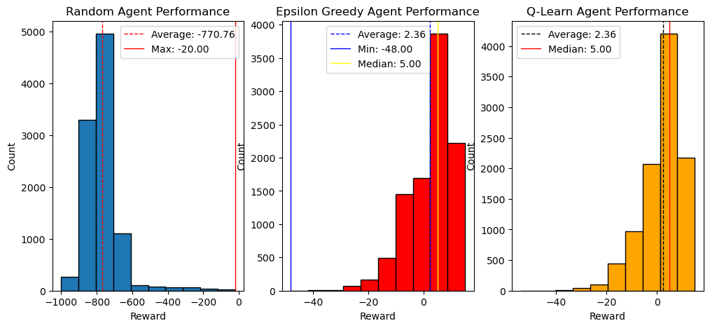

```python
q_learn_rewards = [runEpisodeQAgent(agent) for i in range(10000)]
q_learn_average = np.mean(q_learn_rewards)
e_greedy_median = np.median(e_greedy_agent_rewards)
q_learn_median = np.median(q_learn_rewards)


fig, axs = plt.subplots(ncols=3, figsize=(12, 5))

axs[0].hist(random_rewards, edgecolor='black')
axs[0].set_title("Random Agent Performance")
axs[0].set_xlabel("Reward")
axs[0].set_ylabel("Count")
axs[0].axvline(random_average, color='red', linestyle='dashed', linewidth=1, label=f'Average: {random_average:.2f}')
axs[0].axvline(random_max, color='red', linewidth=1, label=f'Max: {random_max:.2f}')
axs[0].legend()

axs[1].hist(e_greedy_agent_rewards, edgecolor='black', color= 'red')
axs[1].set_title("Epsilon Greedy Agent Performance")
axs[1].set_xlabel("Reward")
axs[1].set_ylabel("Count")
axs[1].axvline(e_greedy_average, color='blue', linestyle='dashed', linewidth=1, label=f'Average: {e_greedy_average:.2f}')
axs[1].axvline(e_greedy_min, color='blue', linewidth=1, label=f'Min: {e_greedy_min:.2f}')
axs[1].axvline(e_greedy_median, color='yellow', linewidth=1, label=f'Median: {e_greedy_median:.2f}')
axs[1].legend()

axs[2].hist(q_learn_rewards, edgecolor='black', color= 'orange')
axs[2].set_title("Q-Learn Agent Performance")
axs[2].set_xlabel("Reward")
axs[2].set_ylabel("Count")
axs[2].axvline(q_learn_average, color='black', linestyle='dashed', linewidth=1, label=f'Average: {q_learn_average:.2f}')
axs[2].axvline(q_learn_median, color='red', linewidth=1, label=f'Median: {q_learn_median:.2f}')
#axs[2].axvline(e_greedy_min, color='black', linewidth=1, label=f'Min: {e_greedy_min:.2f}')
axs[2].legend()

plt.show()
```

## **Performance Comparison**

It appears that the assumption that Epsilon Greedy and Q-Learning would naturally converge to significantly different values was unfounded. As you can observe in the above histograms, the rewards of the two agents are quite similar. The median value is the same, and the averages of the two are quite close to one another. Given this information, it is fair to assume that the two converged to the same (or a very similar) policy.

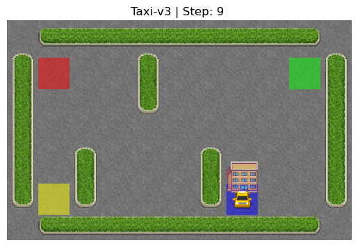

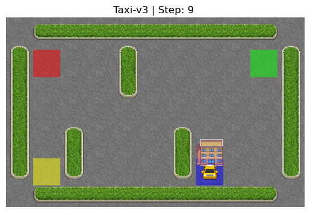

```python
visualizeAgentEpisode(agent, env)
```

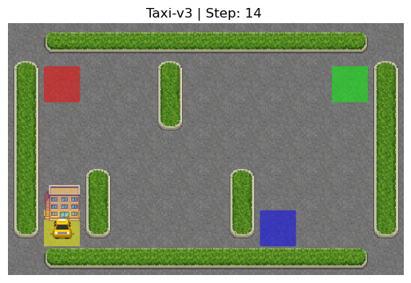

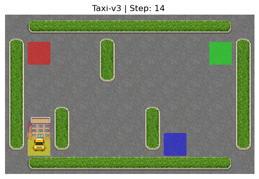

```python
import time
for i in range(10):
    visualizeAgentEpisode(agent, env)
    time.sleep(2)
```

## **Discussion & Conclusion**

For this particular environment, with discrete and finite action spaces and known transition probabilities (every action is guaranteed to succeed), it appears that a Q-Learning agent is sufficient to "solve" the environment to a reasonable degree. As noted above, there is little (if any) difference between a SARSA, on-policy agent and a Q-Learning, off-policy agent within this environment - after training, both perform equally well at completing the task of picking up a passenger and dropping them off at the destination. The histogram of the rewards produced by both models are near identical. In this instance, since the two converged to almost the same policy, it appears that the optimal policy was reached by a Q-Learning agent.

Though more capable model architectures like function-approximating, feature-based models and Deep Q Networks exist, implementing them for this problem would be the subject of future exploration. An additional point for exploration would be solving this problem in an arbitrary environment. For this environment, the setting is fixed, so there is no opportunity to observe if the training generalizes to larger gridworlds.

References:

https://gymnasium.farama.org/environments/toy_text/taxi/

https://gymnasium.farama.org/introduction/train_agent/

https://www.geeksforgeeks.org/differences-between-q-learning-and-sarsa/